# Bio 381 - Computational Biology

*Diana Hackenburg* • *January 17, 2018*

## Welcome to my GitHub project website!

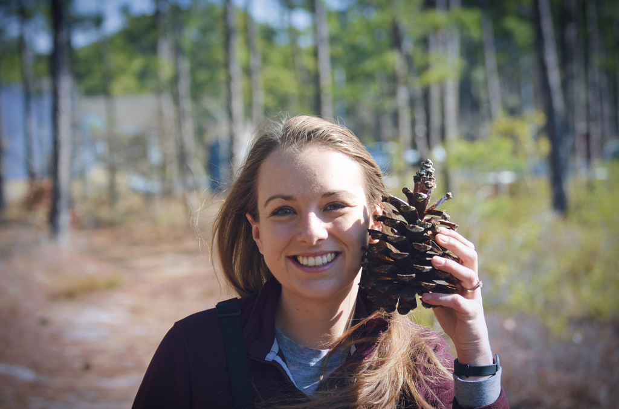

My name is Diana Hackenburg and I am a PhD student in the Rubenstein School at the University of Vermont. I study the connections between human well-being and nature, as well as communication, education and community action related to the environment, specifically algal blooms. Before coming to Vermont, I worked as a science writer/editor with North Carolina Sea Grant, as well as with Triangle Land Conservancy, Virginia Department of Environmental Quality, and the Blue Ridge Land Conservancy. Check out [my other website](https://dianahackenburg.wordpress.com) or email me.

## Presentation

My presentation will be on the timevis and [shiny](https://shiny.rstudio.com/) packages.

- Presentation RMD
- Presentation html
- Data file for timevis demo
- R script for shiny demo
- Check out the [interactive timeline](https://dhackenburg.shinyapps.io/shinyHABtimeline/) I made using timevis and shiny!

## Homework

- Homework 2 - Building flowcharts and other diagrams in Typora
- Homework 3 - Creating a Beamer presentation
- Homework 4 - Scientific programming and simulation using R
- Homework 5 - Working with regular expressions
- Homework 6 - Simulating and fitting data distributions
- Homework 7/8 - Creating fake datasets to explore hypotheses
- Homework 9 - Organizing code with structured programming
- Homework 10 - Batch processing
- Homework 11 - Function plotting and randomization tests
- Homework 12 - ggPlots

## Helpful Links

[Bio 381 website](https://gotellilab.github.io/Bio381)  
[Cheat sheets & programming resources](https://gotellilab.github.io/Bio381/CheatSheets/CheatSheets.html)